# R Programming

## Introduction

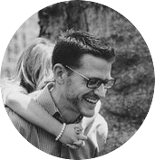

### About Me

- U.S. Air Force - Operations Research Analyst
- Air Force Institute of Technology - Assistant Professor
- University of Cincinnati - Adjunct Assistant Professor
- Website: bradleyboehmke.github.io
- Twitter: [@bradleyboehmke](https://twitter.com/bradleyboehmke)
- Code: [GitHub](https://github.com/bradleyboehmke)

## Short Course Information

### Instructor

- Me

### Time & Location

- Time: Sep 8-16 (RF; M-F) 1600-1700
- Location: Bldg 640 Rm 232

### Website

- Companion website: [afit-r.github.io](http://afit-r.github.io/)
- Slides: afit-r.github.io/oper200

### What are we doing?

- Getting you comfortable at the command line
- Providing basic R Programming literacy

### Requirements

- Computer (AFIT and/or yours)
- R
- IDE (i.e. RStudio)
- Internet (not absolute)

## Short Course Description & Objectives

> *Provides a hands-on introduction to the R programming language. Prepares you with the fundamental programming skills required for today's OR analysts.*

Upon successfully completing this course, you will:

- Be up and running with R
- Understand the different types of data R can work with
- Understand the different structures in which R holds data
- Be able Import data into R
- Perform basic data wrangling activities with R
- Compute basic descriptive statistics with R
- Visualize their data with base R and ggplot graphics

> All required classroom material can be downloaded from:  
> https://github.com/bradleyboehmke/OPER-200

## Getting Started

*“Programming is like kicking yourself in the face, sooner or later your nose will bleed.”*

- Kyle Woodbury

## Installation AFIT PC

> http://rpubs.com/Auburngrads/installAFIT

## Installation Personal PC

1. Go to https://cran.r-project.org/
2. Click "Download R for Mac/Windows"
3. Download the appropriate file:
   - Windows users click Base, and download the installer for the latest R version
   - Mac users select the file R-3.X.X.pkg that aligns with your OS version
4. Follow the instructions of the installer.
1. Go to RStudio for desktop https://www.rstudio.com/products/rstudio/download/
2. Select the install file for your OS
3. Follow the instructions of the installer.

## Demo Time!

[figure not shown]

## Your Turn - #1

> Set your working directory to the "OPER 200" folder you downloaded or created for this course.

## Your Turn - #2

Economic Order Quantity Model: \[Q = \sqrt \frac{2DK}{h}\]

Calculate `Q` where:

- `D = 1000`
- `K = 5`
- `h = 0.25`

hint: `sqrt(x)` \(= \sqrt x\)

## Basic Data Types

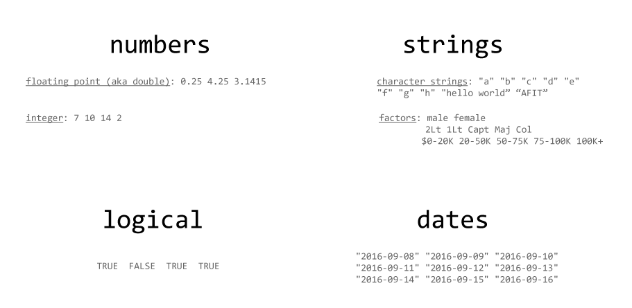

## Vector

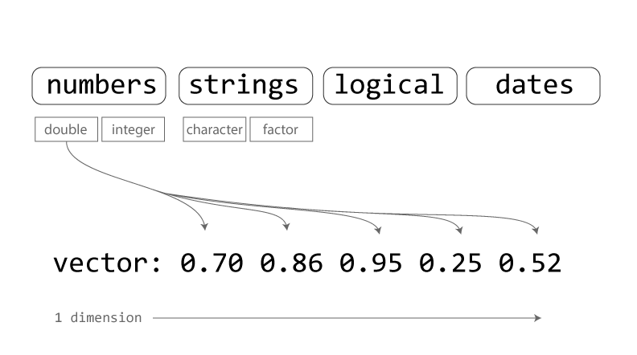

## Your Turn - #3

> 1. type `gallons <- readRDS("data/gallons.rds)` in your console  
> 2. what type of data does this vector contain?  
> 3. how many observations are in the vector  
> 4. what are the names of the vector  
> 5. Remove gallons from your global environment

## Vector Indexing

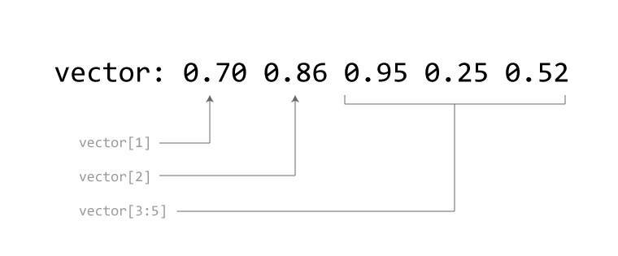

## Your Turn - #4

> 1. load gallons back into your environment  
> 2. index for the 3<sup>rd</sup>-5<sup>th</sup> elements  
> 3. index for aircrafts 12, 17, 38  
> 4. index for elements greater than 50M

## Your Turn - #5

Back to our EOQ Model: \(Q = \sqrt \frac{2DK}{h}\)

1. Calculate `Q` for 3 items where:

- \(D_1 = 900\), \(D_2 = 1000\), \(D_3 = 1450\)
- \(K_1 = 5.5\), \(K_2 = 5\), \(K_3 = 4.5\)
- \(h_1 = 0.25\), \(h_2 = 0.50\), \(h_3 = 0.75\)

2. What is the mean of `Q`?

## Factors

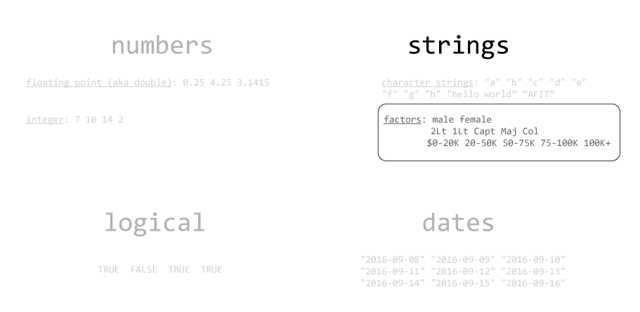

## Your Turn - #6

> 1. type `ses <- readRDS(ses.rds)` in your console  
> 2. what type of data does this vector contain?  
> 3. turn this into an ordered factor with `low < middle < high`  
> 4. how many observations are there for each level?

## Learn More

> https://afit-r.github.io

> » R Basics Section  
> » Data Types Section